# Risk Factor Analysis

## Outcome Variable

**Outcome Variable:** whz

## Predictor Variables

**Intervention Variable:** hdlvry

**Adjustment Set:**

- arm
- sex
- W_mage
- meducyrs
- W_nrooms
- brthmon
- W_parity
- impsan
- delta_W_mage
- delta_meducyrs
- delta_W_nrooms
- delta_brthmon
- delta_W_parity
- delta_impsan

## Stratifying Variables

The analysis was stratified on these variable(s):

- agecat
- studyid
- country

## Data Summary

| agecat | studyid | country | hdlvry | n_cell | n |
| --- | --- | --- | --- | --- | --- |
| Birth | ki1000108-CMC-V-BCS-2002 | INDIA | 0 | 86 | 88 |
| Birth | ki1000108-CMC-V-BCS-2002 | INDIA | 1 | 2 | 88 |
| Birth | ki1000108-IRC | INDIA | 0 | 337 | 343 |
| Birth | ki1000108-IRC | INDIA | 1 | 6 | 343 |
| Birth | ki1000109-EE | PAKISTAN | 0 | 1 | 1 |
| Birth | ki1000109-EE | PAKISTAN | 1 | 0 | 1 |
| Birth | ki1000304b-SAS-CompFeed | INDIA | 0 | 6 | 160 |
| Birth | ki1000304b-SAS-CompFeed | INDIA | 1 | 154 | 160 |
| Birth | ki1017093c-NIH-Crypto | BANGLADESH | 0 | 19 | 23 |
| Birth | ki1017093c-NIH-Crypto | BANGLADESH | 1 | 4 | 23 |
| Birth | ki1135781-COHORTS | INDIA | 0 | 2763 | 4389 |
| Birth | ki1135781-COHORTS | INDIA | 1 | 1626 | 4389 |
| Birth | kiGH5241-JiVitA-3 | BANGLADESH | 0 | 8 | 263 |
| Birth | kiGH5241-JiVitA-3 | BANGLADESH | 1 | 255 | 263 |
| Birth | kiGH5241-JiVitA-4 | BANGLADESH | 0 | 43 | 681 |
| Birth | kiGH5241-JiVitA-4 | BANGLADESH | 1 | 638 | 681 |
| 6 months | ki1000108-CMC-V-BCS-2002 | INDIA | 0 | 357 | 365 |
| 6 months | ki1000108-CMC-V-BCS-2002 | INDIA | 1 | 8 | 365 |
| 6 months | ki1000108-IRC | INDIA | 0 | 400 | 408 |
| 6 months | ki1000108-IRC | INDIA | 1 | 8 | 408 |
| 6 months | ki1000109-EE | PAKISTAN | 0 | 252 | 374 |
| 6 months | ki1000109-EE | PAKISTAN | 1 | 122 | 374 |
| 6 months | ki1000304b-SAS-CompFeed | INDIA | 0 | 147 | 1088 |
| 6 months | ki1000304b-SAS-CompFeed | INDIA | 1 | 941 | 1088 |
| 6 months | ki1000304b-SAS-FoodSuppl | INDIA | 0 | 76 | 380 |
| 6 months | ki1000304b-SAS-FoodSuppl | INDIA | 1 | 304 | 380 |
| 6 months | ki1017093b-PROVIDE | BANGLADESH | 0 | 433 | 582 |
| 6 months | ki1017093b-PROVIDE | BANGLADESH | 1 | 149 | 582 |
| 6 months | ki1017093c-NIH-Crypto | BANGLADESH | 0 | 554 | 715 |
| 6 months | ki1017093c-NIH-Crypto | BANGLADESH | 1 | 161 | 715 |
| 6 months | ki1066203-TanzaniaChild2 | TANZANIA, UNITED REPUBLIC OF | 0 | 1888 | 1920 |
| 6 months | ki1066203-TanzaniaChild2 | TANZANIA, UNITED REPUBLIC OF | 1 | 32 | 1920 |
| 6 months | ki1113344-GMS-Nepal | NEPAL | 0 | 129 | 527 |
| 6 months | ki1113344-GMS-Nepal | NEPAL | 1 | 398 | 527 |
| 6 months | ki1135781-COHORTS | INDIA | 0 | 2896 | 4694 |
| 6 months | ki1135781-COHORTS | INDIA | 1 | 1798 | 4694 |
| 6 months | kiGH5241-JiVitA-3 | BANGLADESH | 0 | 39 | 334 |
| 6 months | kiGH5241-JiVitA-3 | BANGLADESH | 1 | 295 | 334 |
| 6 months | kiGH5241-JiVitA-4 | BANGLADESH | 0 | 1082 | 4042 |
| 6 months | kiGH5241-JiVitA-4 | BANGLADESH | 1 | 2960 | 4042 |
| 24 months | ki1000108-CMC-V-BCS-2002 | INDIA | 0 | 361 | 369 |
| 24 months | ki1000108-CMC-V-BCS-2002 | INDIA | 1 | 8 | 369 |
| 24 months | ki1000108-IRC | INDIA | 0 | 401 | 409 |
| 24 months | ki1000108-IRC | INDIA | 1 | 8 | 409 |
| 24 months | ki1017093b-PROVIDE | BANGLADESH | 0 | 432 | 578 |
| 24 months | ki1017093b-PROVIDE | BANGLADESH | 1 | 146 | 578 |
| 24 months | ki1017093c-NIH-Crypto | BANGLADESH | 0 | 391 | 514 |
| 24 months | ki1017093c-NIH-Crypto | BANGLADESH | 1 | 123 | 514 |
| 24 months | ki1066203-TanzaniaChild2 | TANZANIA, UNITED REPUBLIC OF | 0 | 6 | 6 |
| 24 months | ki1066203-TanzaniaChild2 | TANZANIA, UNITED REPUBLIC OF | 1 | 0 | 6 |
| 24 months | ki1113344-GMS-Nepal | NEPAL | 0 | 120 | 466 |
| 24 months | ki1113344-GMS-Nepal | NEPAL | 1 | 346 | 466 |
| 24 months | ki1135781-COHORTS | INDIA | 0 | 2214 | 3533 |
| 24 months | ki1135781-COHORTS | INDIA | 1 | 1319 | 3533 |
| 24 months | kiGH5241-JiVitA-3 | BANGLADESH | 0 | 34 | 289 |
| 24 months | kiGH5241-JiVitA-3 | BANGLADESH | 1 | 255 | 289 |
| 24 months | kiGH5241-JiVitA-4 | BANGLADESH | 0 | 1032 | 3993 |
| 24 months | kiGH5241-JiVitA-4 | BANGLADESH | 1 | 2961 | 3993 |

The following strata were considered:

- agecat: 24 months, studyid: ki1000108-CMC-V-BCS-2002, country: INDIA
- agecat: 24 months, studyid: ki1000108-IRC, country: INDIA
- agecat: 24 months, studyid: ki1017093b-PROVIDE, country: BANGLADESH
- agecat: 24 months, studyid: ki1017093c-NIH-Crypto, country: BANGLADESH
- agecat: 24 months, studyid: ki1066203-TanzaniaChild2, country: TANZANIA, UNITED REPUBLIC OF
- agecat: 24 months, studyid: ki1113344-GMS-Nepal, country: NEPAL
- agecat: 24 months, studyid: ki1135781-COHORTS, country: INDIA
- agecat: 24 months, studyid: kiGH5241-JiVitA-3, country: BANGLADESH
- agecat: 24 months, studyid: kiGH5241-JiVitA-4, country: BANGLADESH
- agecat: 6 months, studyid: ki1000108-CMC-V-BCS-2002, country: INDIA
- agecat: 6 months, studyid: ki1000108-IRC, country: INDIA
- agecat: 6 months, studyid: ki1000109-EE, country: PAKISTAN
- agecat: 6 months, studyid: ki1000304b-SAS-CompFeed, country: INDIA
- agecat: 6 months, studyid: ki1000304b-SAS-FoodSuppl, country: INDIA
- agecat: 6 months, studyid: ki1017093b-PROVIDE, country: BANGLADESH
- agecat: 6 months, studyid: ki1017093c-NIH-Crypto, country: BANGLADESH
- agecat: 6 months, studyid: ki1066203-TanzaniaChild2, country: TANZANIA, UNITED REPUBLIC OF
- agecat: 6 months, studyid: ki1113344-GMS-Nepal, country: NEPAL
- agecat: 6 months, studyid: ki1135781-COHORTS, country: INDIA
- agecat: 6 months, studyid: kiGH5241-JiVitA-3, country: BANGLADESH
- agecat: 6 months, studyid: kiGH5241-JiVitA-4, country: BANGLADESH
- agecat: Birth, studyid: ki1000108-CMC-V-BCS-2002, country: INDIA
- agecat: Birth, studyid: ki1000108-IRC, country: INDIA
- agecat: Birth, studyid: ki1000109-EE, country: PAKISTAN
- agecat: Birth, studyid: ki1000304b-SAS-CompFeed, country: INDIA
- agecat: Birth, studyid: ki1017093c-NIH-Crypto, country: BANGLADESH
- agecat: Birth, studyid: ki1135781-COHORTS, country: INDIA
- agecat: Birth, studyid: kiGH5241-JiVitA-3, country: BANGLADESH
- agecat: Birth, studyid: kiGH5241-JiVitA-4, country: BANGLADESH

### Dropped Strata

Some strata were dropped due to rare outcomes:

- agecat: Birth, studyid: ki1000108-CMC-V-BCS-2002, country: INDIA
- agecat: Birth, studyid: ki1000109-EE, country: PAKISTAN
- agecat: Birth, studyid: ki1017093c-NIH-Crypto, country: BANGLADESH
- agecat: 24 months, studyid: ki1066203-TanzaniaChild2, country: TANZANIA, UNITED REPUBLIC OF

## Methods Detail

We’re interested in the causal parameters $E[Y_a]$ for all values of $a \in \mathcal{A}$. These parameters represent the mean outcome if, possibly contrary to fact, we intervened to set all units to have $A=a$. Under the randomization and positivity assumptions, these are identified by the statistical parameters $\psi_a=E_W[E_{Y|A,W}(Y|A=a,W)]$. In addition, we’re interested in the mean of $Y$, $E[Y]$ under no intervention (the observed mean). We will estimate these parameters by using SuperLearner to fit the relevant likelihood factors – $E_{Y|A,W}(Y|A=a,W)$ and $p(A=a|W)$, and then updating our likelihood fit using a joint TMLE.

For unadjusted analyses ($W=\{\}$), initial likelihoods were estimated using Lrnr_glm to estimate the simple $E(Y|A)$ and Lrnr_mean to estimate $p(A)$. For adjusted analyses, a small library containing Lrnr_glmnet, Lrnr_xgboost, and Lrnr_mean was used.

Having estimated these parameters, we will then use the delta method to estimate relative risks and attributable risks relative to a prespecified baseline level of $A$.

# Results Detail

## Results Plots

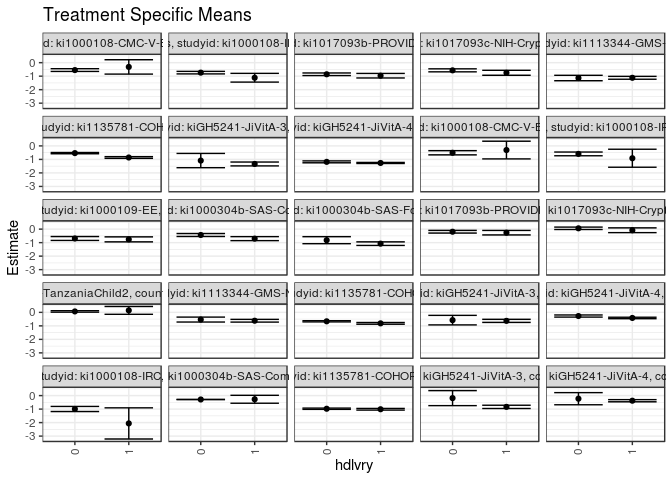

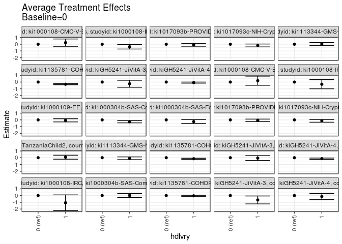

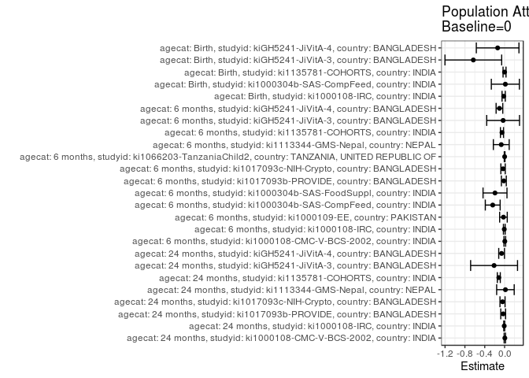

## Results Table

### Parameter: TSM

| agecat | studyid | country | intervention_level | baseline_level | estimate | ci_lower | ci_upper |
| --- | --- | --- | --- | --- | --- | --- | --- |
| Birth | ki1000108-IRC | INDIA | 0 | NA | -0.9918991 | -1.1804921 | -0.8033061 |
| Birth | ki1000108-IRC | INDIA | 1 | NA | -2.0600000 | -3.2141159 | -0.9058841 |
| Birth | ki1000304b-SAS-CompFeed | INDIA | 0 | NA | -0.2883333 | -0.2883333 | -0.2883333 |
| Birth | ki1000304b-SAS-CompFeed | INDIA | 1 | NA | -0.2725325 | -0.5663796 | 0.0213146 |
| Birth | ki1135781-COHORTS | INDIA | 0 | NA | -0.9744245 | -1.0210681 | -0.9277810 |
| Birth | ki1135781-COHORTS | INDIA | 1 | NA | -1.0115987 | -1.0737458 | -0.9494516 |
| Birth | kiGH5241-JiVitA-3 | BANGLADESH | 0 | NA | -0.1862500 | -0.7425559 | 0.3700559 |
| Birth | kiGH5241-JiVitA-3 | BANGLADESH | 1 | NA | -0.8360392 | -0.9570005 | -0.7150779 |
| Birth | kiGH5241-JiVitA-4 | BANGLADESH | 0 | NA | -0.2301529 | -0.6807475 | 0.2204418 |
| Birth | kiGH5241-JiVitA-4 | BANGLADESH | 1 | NA | -0.3787171 | -0.4596021 | -0.2978321 |
| 6 months | ki1000108-CMC-V-BCS-2002 | INDIA | 0 | NA | -0.5089262 | -0.6640006 | -0.3538519 |
| 6 months | ki1000108-CMC-V-BCS-2002 | INDIA | 1 | NA | -0.3072917 | -0.9616161 | 0.3470328 |
| 6 months | ki1000108-IRC | INDIA | 0 | NA | -0.5926333 | -0.7305001 | -0.4547666 |
| 6 months | ki1000108-IRC | INDIA | 1 | NA | -0.9137500 | -1.5807163 | -0.2467837 |
| 6 months | ki1000109-EE | PAKISTAN | 0 | NA | -0.6927404 | -0.8365277 | -0.5489531 |
| 6 months | ki1000109-EE | PAKISTAN | 1 | NA | -0.7585941 | -0.9433544 | -0.5738339 |
| 6 months | ki1000304b-SAS-CompFeed | INDIA | 0 | NA | -0.4341789 | -0.5428942 | -0.3254636 |
| 6 months | ki1000304b-SAS-CompFeed | INDIA | 1 | NA | -0.7040005 | -0.8519652 | -0.5560358 |
| 6 months | ki1000304b-SAS-FoodSuppl | INDIA | 0 | NA | -0.8188539 | -1.0800868 | -0.5576211 |
| 6 months | ki1000304b-SAS-FoodSuppl | INDIA | 1 | NA | -1.0756291 | -1.2072728 | -0.9439854 |
| 6 months | ki1017093b-PROVIDE | BANGLADESH | 0 | NA | -0.1933127 | -0.2915300 | -0.0950954 |
| 6 months | ki1017093b-PROVIDE | BANGLADESH | 1 | NA | -0.2640601 | -0.4304964 | -0.0976239 |
| 6 months | ki1017093c-NIH-Crypto | BANGLADESH | 0 | NA | 0.0603752 | -0.0289475 | 0.1496979 |
| 6 months | ki1017093c-NIH-Crypto | BANGLADESH | 1 | NA | -0.0837365 | -0.2608003 | 0.0933273 |
| 6 months | ki1066203-TanzaniaChild2 | TANZANIA, UNITED REPUBLIC OF | 0 | NA | 0.0682330 | 0.0131853 | 0.1232808 |
| 6 months | ki1066203-TanzaniaChild2 | TANZANIA, UNITED REPUBLIC OF | 1 | NA | 0.1467033 | -0.1430758 | 0.4364824 |
| 6 months | ki1113344-GMS-Nepal | NEPAL | 0 | NA | -0.5332252 | -0.7149376 | -0.3515128 |
| 6 months | ki1113344-GMS-Nepal | NEPAL | 1 | NA | -0.6203525 | -0.7222704 | -0.5184346 |
| 6 months | ki1135781-COHORTS | INDIA | 0 | NA | -0.6630438 | -0.7078927 | -0.6181949 |
| 6 months | ki1135781-COHORTS | INDIA | 1 | NA | -0.8137906 | -0.8764926 | -0.7510886 |
| 6 months | kiGH5241-JiVitA-3 | BANGLADESH | 0 | NA | -0.5747206 | -0.9274516 | -0.2219896 |
| 6 months | kiGH5241-JiVitA-3 | BANGLADESH | 1 | NA | -0.6296124 | -0.7432489 | -0.5159760 |
| 6 months | kiGH5241-JiVitA-4 | BANGLADESH | 0 | NA | -0.2721689 | -0.3515706 | -0.1927671 |
| 6 months | kiGH5241-JiVitA-4 | BANGLADESH | 1 | NA | -0.4140475 | -0.4684127 | -0.3596824 |
| 24 months | ki1000108-CMC-V-BCS-2002 | INDIA | 0 | NA | -0.5487673 | -0.6500596 | -0.4474751 |
| 24 months | ki1000108-CMC-V-BCS-2002 | INDIA | 1 | NA | -0.3150000 | -0.8468853 | 0.2168853 |
| 24 months | ki1000108-IRC | INDIA | 0 | NA | -0.7384331 | -0.8312559 | -0.6456103 |
| 24 months | ki1000108-IRC | INDIA | 1 | NA | -1.1158333 | -1.4387631 | -0.7929036 |
| 24 months | ki1017093b-PROVIDE | BANGLADESH | 0 | NA | -0.8595700 | -0.9550634 | -0.7640766 |
| 24 months | ki1017093b-PROVIDE | BANGLADESH | 1 | NA | -0.9655335 | -1.1344742 | -0.7965927 |
| 24 months | ki1017093c-NIH-Crypto | BANGLADESH | 0 | NA | -0.5685258 | -0.6788888 | -0.4581627 |
| 24 months | ki1017093c-NIH-Crypto | BANGLADESH | 1 | NA | -0.7499021 | -0.9332395 | -0.5665648 |
| 24 months | ki1113344-GMS-Nepal | NEPAL | 0 | NA | -1.1366887 | -1.3386424 | -0.9347350 |
| 24 months | ki1113344-GMS-Nepal | NEPAL | 1 | NA | -1.1210122 | -1.2264469 | -1.0155775 |
| 24 months | ki1135781-COHORTS | INDIA | 0 | NA | -0.5352301 | -0.5800094 | -0.4904508 |
| 24 months | ki1135781-COHORTS | INDIA | 1 | NA | -0.8593396 | -0.9204326 | -0.7982465 |
| 24 months | kiGH5241-JiVitA-3 | BANGLADESH | 0 | NA | -1.0870011 | -1.6153867 | -0.5586155 |
| 24 months | kiGH5241-JiVitA-3 | BANGLADESH | 1 | NA | -1.3375271 | -1.4812777 | -1.1937765 |
| 24 months | kiGH5241-JiVitA-4 | BANGLADESH | 0 | NA | -1.1818625 | -1.2509585 | -1.1127664 |
| 24 months | kiGH5241-JiVitA-4 | BANGLADESH | 1 | NA | -1.2635733 | -1.3024166 | -1.2247300 |

### Parameter: E(Y)

| agecat | studyid | country | intervention_level | baseline_level | estimate | ci_lower | ci_upper |
| --- | --- | --- | --- | --- | --- | --- | --- |
| Birth | ki1000108-IRC | INDIA | NA | NA | -1.0105831 | -1.1973019 | -0.8238643 |
| Birth | ki1000304b-SAS-CompFeed | INDIA | NA | NA | -0.2731250 | -0.5556221 | 0.0093721 |
| Birth | ki1135781-COHORTS | INDIA | NA | NA | -0.9755867 | -1.0106993 | -0.9404741 |
| Birth | kiGH5241-JiVitA-3 | BANGLADESH | NA | NA | -0.8162738 | -0.9311489 | -0.7013987 |
| Birth | kiGH5241-JiVitA-4 | BANGLADESH | NA | NA | -0.3701909 | -0.4509242 | -0.2894576 |
| 6 months | ki1000108-CMC-V-BCS-2002 | INDIA | NA | NA | -0.5045068 | -0.6566169 | -0.3523968 |
| 6 months | ki1000108-IRC | INDIA | NA | NA | -0.5989297 | -0.7344491 | -0.4634104 |
| 6 months | ki1000109-EE | PAKISTAN | NA | NA | -0.7158824 | -0.8295258 | -0.6022389 |
| 6 months | ki1000304b-SAS-CompFeed | INDIA | NA | NA | -0.6734421 | -0.8121314 | -0.5347528 |
| 6 months | ki1000304b-SAS-FoodSuppl | INDIA | NA | NA | -1.0121579 | -1.1280429 | -0.8962729 |
| 6 months | ki1017093b-PROVIDE | BANGLADESH | NA | NA | -0.2083706 | -0.2927992 | -0.1239419 |
| 6 months | ki1017093c-NIH-Crypto | BANGLADESH | NA | NA | 0.0297622 | -0.0491685 | 0.1086930 |
| 6 months | ki1066203-TanzaniaChild2 | TANZANIA, UNITED REPUBLIC OF | NA | NA | 0.0688763 | 0.0147308 | 0.1230218 |
| 6 months | ki1113344-GMS-Nepal | NEPAL | NA | NA | -0.6002688 | -0.6889771 | -0.5115605 |
| 6 months | ki1135781-COHORTS | INDIA | NA | NA | -0.7160077 | -0.7492815 | -0.6827338 |
| 6 months | kiGH5241-JiVitA-3 | BANGLADESH | NA | NA | -0.6044910 | -0.7122040 | -0.4967781 |
| 6 months | kiGH5241-JiVitA-4 | BANGLADESH | NA | NA | -0.3760651 | -0.4191017 | -0.3330285 |
| 24 months | ki1000108-CMC-V-BCS-2002 | INDIA | NA | NA | -0.5436992 | -0.6434110 | -0.4439874 |
| 24 months | ki1000108-IRC | INDIA | NA | NA | -0.7458150 | -0.8368180 | -0.6548120 |
| 24 months | ki1017093b-PROVIDE | BANGLADESH | NA | NA | -0.8879412 | -0.9708680 | -0.8050144 |
| 24 months | ki1017093c-NIH-Crypto | BANGLADESH | NA | NA | -0.6103502 | -0.7050157 | -0.5156847 |
| 24 months | ki1113344-GMS-Nepal | NEPAL | NA | NA | -1.1197461 | -1.2105714 | -1.0289207 |
| 24 months | ki1135781-COHORTS | INDIA | NA | NA | -0.6520577 | -0.6860033 | -0.6181122 |
| 24 months | kiGH5241-JiVitA-3 | BANGLADESH | NA | NA | -1.2989273 | -1.4377964 | -1.1600583 |
| 24 months | kiGH5241-JiVitA-4 | BANGLADESH | NA | NA | -1.2421463 | -1.2763113 | -1.2079812 |

### Parameter: ATE

| agecat | studyid | country | intervention_level | baseline_level | estimate | ci_lower | ci_upper |
| --- | --- | --- | --- | --- | --- | --- | --- |
| Birth | ki1000108-IRC | INDIA | 0 | 0 | 0.0000000 | 0.0000000 | 0.0000000 |
| Birth | ki1000108-IRC | INDIA | 1 | 0 | -1.0681009 | -2.2375241 | 0.1013224 |
| Birth | ki1000304b-SAS-CompFeed | INDIA | 0 | 0 | 0.0000000 | 0.0000000 | 0.0000000 |
| Birth | ki1000304b-SAS-CompFeed | INDIA | 1 | 0 | 0.0158009 | -0.2780462 | 0.3096480 |
| Birth | ki1135781-COHORTS | INDIA | 0 | 0 | 0.0000000 | 0.0000000 | 0.0000000 |
| Birth | ki1135781-COHORTS | INDIA | 1 | 0 | -0.0371742 | -0.1147273 | 0.0403789 |
| Birth | kiGH5241-JiVitA-3 | BANGLADESH | 0 | 0 | 0.0000000 | 0.0000000 | 0.0000000 |
| Birth | kiGH5241-JiVitA-3 | BANGLADESH | 1 | 0 | -0.6497892 | -1.2375156 | -0.0620629 |
| Birth | kiGH5241-JiVitA-4 | BANGLADESH | 0 | 0 | 0.0000000 | 0.0000000 | 0.0000000 |
| Birth | kiGH5241-JiVitA-4 | BANGLADESH | 1 | 0 | -0.1485642 | -0.6072101 | 0.3100817 |
| 6 months | ki1000108-CMC-V-BCS-2002 | INDIA | 0 | 0 | 0.0000000 | 0.0000000 | 0.0000000 |
| 6 months | ki1000108-CMC-V-BCS-2002 | INDIA | 1 | 0 | 0.2016346 | -0.4708151 | 0.8740843 |
| 6 months | ki1000108-IRC | INDIA | 0 | 0 | 0.0000000 | 0.0000000 | 0.0000000 |
| 6 months | ki1000108-IRC | INDIA | 1 | 0 | -0.3211167 | -1.0021830 | 0.3599496 |
| 6 months | ki1000109-EE | PAKISTAN | 0 | 0 | 0.0000000 | 0.0000000 | 0.0000000 |
| 6 months | ki1000109-EE | PAKISTAN | 1 | 0 | -0.0658537 | -0.3003878 | 0.1686803 |
| 6 months | ki1000304b-SAS-CompFeed | INDIA | 0 | 0 | 0.0000000 | 0.0000000 | 0.0000000 |
| 6 months | ki1000304b-SAS-CompFeed | INDIA | 1 | 0 | -0.2698216 | -0.4413566 | -0.0982867 |
| 6 months | ki1000304b-SAS-FoodSuppl | INDIA | 0 | 0 | 0.0000000 | 0.0000000 | 0.0000000 |
| 6 months | ki1000304b-SAS-FoodSuppl | INDIA | 1 | 0 | -0.2567752 | -0.5488898 | 0.0353395 |
| 6 months | ki1017093b-PROVIDE | BANGLADESH | 0 | 0 | 0.0000000 | 0.0000000 | 0.0000000 |
| 6 months | ki1017093b-PROVIDE | BANGLADESH | 1 | 0 | -0.0707475 | -0.2638784 | 0.1223834 |
| 6 months | ki1017093c-NIH-Crypto | BANGLADESH | 0 | 0 | 0.0000000 | 0.0000000 | 0.0000000 |
| 6 months | ki1017093c-NIH-Crypto | BANGLADESH | 1 | 0 | -0.1441117 | -0.3435169 | 0.0552934 |
| 6 months | ki1066203-TanzaniaChild2 | TANZANIA, UNITED REPUBLIC OF | 0 | 0 | 0.0000000 | 0.0000000 | 0.0000000 |
| 6 months | ki1066203-TanzaniaChild2 | TANZANIA, UNITED REPUBLIC OF | 1 | 0 | 0.0784702 | -0.2163973 | 0.3733378 |
| 6 months | ki1113344-GMS-Nepal | NEPAL | 0 | 0 | 0.0000000 | 0.0000000 | 0.0000000 |
| 6 months | ki1113344-GMS-Nepal | NEPAL | 1 | 0 | -0.0871273 | -0.2964938 | 0.1222392 |
| 6 months | ki1135781-COHORTS | INDIA | 0 | 0 | 0.0000000 | 0.0000000 | 0.0000000 |
| 6 months | ki1135781-COHORTS | INDIA | 1 | 0 | -0.1507468 | -0.2276979 | -0.0737958 |
| 6 months | kiGH5241-JiVitA-3 | BANGLADESH | 0 | 0 | 0.0000000 | 0.0000000 | 0.0000000 |
| 6 months | kiGH5241-JiVitA-3 | BANGLADESH | 1 | 0 | -0.0548919 | -0.4153524 | 0.3055687 |
| 6 months | kiGH5241-JiVitA-4 | BANGLADESH | 0 | 0 | 0.0000000 | 0.0000000 | 0.0000000 |
| 6 months | kiGH5241-JiVitA-4 | BANGLADESH | 1 | 0 | -0.1418787 | -0.2360197 | -0.0477376 |
| 24 months | ki1000108-CMC-V-BCS-2002 | INDIA | 0 | 0 | 0.0000000 | 0.0000000 | 0.0000000 |
| 24 months | ki1000108-CMC-V-BCS-2002 | INDIA | 1 | 0 | 0.2337673 | -0.3076771 | 0.7752117 |
| 24 months | ki1000108-IRC | INDIA | 0 | 0 | 0.0000000 | 0.0000000 | 0.0000000 |
| 24 months | ki1000108-IRC | INDIA | 1 | 0 | -0.3774002 | -0.7134057 | -0.0413948 |
| 24 months | ki1017093b-PROVIDE | BANGLADESH | 0 | 0 | 0.0000000 | 0.0000000 | 0.0000000 |
| 24 months | ki1017093b-PROVIDE | BANGLADESH | 1 | 0 | -0.1059635 | -0.3000245 | 0.0880976 |
| 24 months | ki1017093c-NIH-Crypto | BANGLADESH | 0 | 0 | 0.0000000 | 0.0000000 | 0.0000000 |
| 24 months | ki1017093c-NIH-Crypto | BANGLADESH | 1 | 0 | -0.1813764 | -0.3952907 | 0.0325380 |
| 24 months | ki1113344-GMS-Nepal | NEPAL | 0 | 0 | 0.0000000 | 0.0000000 | 0.0000000 |
| 24 months | ki1113344-GMS-Nepal | NEPAL | 1 | 0 | 0.0156765 | -0.2126203 | 0.2439734 |
| 24 months | ki1135781-COHORTS | INDIA | 0 | 0 | 0.0000000 | 0.0000000 | 0.0000000 |
| 24 months | ki1135781-COHORTS | INDIA | 1 | 0 | -0.3241095 | -0.3997179 | -0.2485011 |
| 24 months | kiGH5241-JiVitA-3 | BANGLADESH | 0 | 0 | 0.0000000 | 0.0000000 | 0.0000000 |
| 24 months | kiGH5241-JiVitA-3 | BANGLADESH | 1 | 0 | -0.2505260 | -0.7671608 | 0.2661088 |
| 24 months | kiGH5241-JiVitA-4 | BANGLADESH | 0 | 0 | 0.0000000 | 0.0000000 | 0.0000000 |
| 24 months | kiGH5241-JiVitA-4 | BANGLADESH | 1 | 0 | -0.0817108 | -0.1597421 | -0.0036796 |

### Parameter: PAR

| agecat | studyid | country | intervention_level | baseline_level | estimate | ci_lower | ci_upper |
| --- | --- | --- | --- | --- | --- | --- | --- |
| Birth | ki1000108-IRC | INDIA | 0 | NA | -0.0186840 | -0.0514705 | 0.0141025 |
| Birth | ki1000304b-SAS-CompFeed | INDIA | 0 | NA | 0.0152083 | -0.2672888 | 0.2977055 |
| Birth | ki1135781-COHORTS | INDIA | 0 | NA | -0.0011622 | -0.0311891 | 0.0288648 |
| Birth | kiGH5241-JiVitA-3 | BANGLADESH | 0 | NA | -0.6300238 | -1.2012946 | -0.0587529 |
| Birth | kiGH5241-JiVitA-4 | BANGLADESH | 0 | NA | -0.1400380 | -0.5695629 | 0.2894868 |
| 6 months | ki1000108-CMC-V-BCS-2002 | INDIA | 0 | NA | 0.0044194 | -0.0126632 | 0.0215020 |
| 6 months | ki1000108-IRC | INDIA | 0 | NA | -0.0062964 | -0.0238639 | 0.0112711 |
| 6 months | ki1000109-EE | PAKISTAN | 0 | NA | -0.0231420 | -0.0997094 | 0.0534255 |
| 6 months | ki1000304b-SAS-CompFeed | INDIA | 0 | NA | -0.2392632 | -0.3886169 | -0.0899096 |
| 6 months | ki1000304b-SAS-FoodSuppl | INDIA | 0 | NA | -0.1933040 | -0.4345600 | 0.0479521 |
| 6 months | ki1017093b-PROVIDE | BANGLADESH | 0 | NA | -0.0150579 | -0.0642234 | 0.0341076 |
| 6 months | ki1017093c-NIH-Crypto | BANGLADESH | 0 | NA | -0.0306130 | -0.0750120 | 0.0137860 |
| 6 months | ki1066203-TanzaniaChild2 | TANZANIA, UNITED REPUBLIC OF | 0 | NA | 0.0006433 | -0.0066727 | 0.0079592 |
| 6 months | ki1113344-GMS-Nepal | NEPAL | 0 | NA | -0.0670436 | -0.2268159 | 0.0927286 |
| 6 months | ki1135781-COHORTS | INDIA | 0 | NA | -0.0529639 | -0.0839340 | -0.0219937 |
| 6 months | kiGH5241-JiVitA-3 | BANGLADESH | 0 | NA | -0.0297704 | -0.3603044 | 0.3007635 |
| 6 months | kiGH5241-JiVitA-4 | BANGLADESH | 0 | NA | -0.1038962 | -0.1709059 | -0.0368865 |
| 24 months | ki1000108-CMC-V-BCS-2002 | INDIA | 0 | NA | 0.0050681 | -0.0089078 | 0.0190440 |
| 24 months | ki1000108-IRC | INDIA | 0 | NA | -0.0073819 | -0.0171941 | 0.0024303 |
| 24 months | ki1017093b-PROVIDE | BANGLADESH | 0 | NA | -0.0283712 | -0.0770710 | 0.0203287 |
| 24 months | ki1017093c-NIH-Crypto | BANGLADESH | 0 | NA | -0.0418244 | -0.0929930 | 0.0093442 |
| 24 months | ki1113344-GMS-Nepal | NEPAL | 0 | NA | 0.0169427 | -0.1597938 | 0.1936792 |
| 24 months | ki1135781-COHORTS | INDIA | 0 | NA | -0.1168276 | -0.1468872 | -0.0867680 |
| 24 months | kiGH5241-JiVitA-3 | BANGLADESH | 0 | NA | -0.2119263 | -0.6844464 | 0.2605939 |
| 24 months | kiGH5241-JiVitA-4 | BANGLADESH | 0 | NA | -0.0602838 | -0.1181302 | -0.0024374 |